# Introduction to R Data Analysis

Part 2

Natalie Gill

### Gladstone Bioinformatics Core August 22nd, 2025

*Press the ? key for tips on navigating these slides*

# Introductions

**Natalie Gill**  
Bioinformatician II

# Schedule

1. Introduction to Tidyverse
2. Filtering and reformatting data
3. Plotting data
4. Hands on data analysis
5. AI tips for R
6. Where to get help

# Introduction to Tidyverse

## Tidyverse

- The tidyverse packages work well together because they share common data representations and design principles
  - Rows = observations, columns = variables
- [ggplot2](https://ggplot2.tidyverse.org/), for data visualization.
- [dplyr](https://dplyr.tidyverse.org/), for data manipulation.
- [tidyr](https://tidyr.tidyverse.org/), for data tidying.
- [readr](https://readr.tidyverse.org/), for data import.
- [purrr](https://purrr.tidyverse.org/), for iteration.
- and more..

## dplyr

- Offers a common “grammar” of functions for data manipulation
  - [mutate()](https://dplyr.tidyverse.org/reference/mutate.html) adds new variables that are functions of existing columns
  - [select()](https://dplyr.tidyverse.org/reference/select.html) picks columns based on their names
  - [filter()](https://dplyr.tidyverse.org/reference/filter.html) picks rows based on their values
  - [summarise()](https://dplyr.tidyverse.org/reference/summarise.html) reduces multiple values down to a single summary
  - [arrange()](https://dplyr.tidyverse.org/reference/arrange.html) changes the ordering of the rows
  - [group_by()](https://dplyr.tidyverse.org/reference/group_by.html) allows any operation to be done “by group”

## Example Dataframe

- mpg is a dataframe built into the ggplot2 package

```r
head(mpg)
```

```
# A tibble: 6 × 11
  manufacturer model displ  year   cyl trans      drv     cty   hwy fl    class
  <chr>        <chr> <dbl> <int> <int> <chr>      <chr> <int> <int> <chr> <chr>
1 audi         a4      1.8  1999     4 auto(l5)   f        18    29 p     compa…
2 audi         a4      1.8  1999     4 manual(m5) f        21    29 p     compa…
3 audi         a4      2    2008     4 manual(m6) f        20    31 p     compa…
4 audi         a4      2    2008     4 auto(av)   f        21    30 p     compa…
5 audi         a4      2.8  1999     6 auto(l5)   f        16    26 p     compa…
6 audi         a4      2.8  1999     6 manual(m5) f        18    26 p     compa…
```

## Select Columns

```r
select(.data = mpg,
       year, cty, hwy, manufacturer)
```

```
# A tibble: 234 × 4
    year   cty   hwy manufacturer
   <int> <int> <int> <chr>
 1  1999    18    29 audi
 2  1999    21    29 audi
 3  2008    20    31 audi
 4  2008    21    30 audi
 5  1999    16    26 audi
 6  1999    18    26 audi
 7  2008    18    27 audi
 8  1999    18    26 audi
 9  1999    16    25 audi
10  2008    20    28 audi
# ℹ 224 more rows
```

## Filter Rows

```r
filter(.data = mpg,
       year == 2008)
```

```
# A tibble: 117 × 11
   manufacturer model      displ  year   cyl trans drv     cty   hwy fl    class
   <chr>        <chr>      <dbl> <int> <int> <chr> <chr> <int> <int> <chr> <chr>
 1 audi         a4           2    2008     4 manu… f        20    31 p     comp…
 2 audi         a4           2    2008     4 auto… f        21    30 p     comp…
 3 audi         a4           3.1  2008     6 auto… f        18    27 p     comp…
 4 audi         a4 quattro   2    2008     4 manu… 4        20    28 p     comp…
 5 audi         a4 quattro   2    2008     4 auto… 4        19    27 p     comp…
 6 audi         a4 quattro   3.1  2008     6 auto… 4        17    25 p     comp…
 7 audi         a4 quattro   3.1  2008     6 manu… 4        15    25 p     comp…
 8 audi         a6 quattro   3.1  2008     6 auto… 4        17    25 p     mids…
 9 audi         a6 quattro   4.2  2008     8 auto… 4        16    23 p     mids…
10 chevrolet    c1500 sub…   5.3  2008     8 auto… r        14    20 r     suv
# ℹ 107 more rows
```

## Arrange Rows

- desc() is used to arrange rows in descending order, the default is ascending

```r
arrange(.data = mpg,
        desc(cty))
```

```
# A tibble: 234 × 11
   manufacturer model      displ  year   cyl trans drv     cty   hwy fl    class
   <chr>        <chr>      <dbl> <int> <int> <chr> <chr> <int> <int> <chr> <chr>
 1 volkswagen   new beetle   1.9  1999     4 manu… f        35    44 d     subc…
 2 volkswagen   jetta        1.9  1999     4 manu… f        33    44 d     comp…
 3 volkswagen   new beetle   1.9  1999     4 auto… f        29    41 d     subc…
 4 honda        civic        1.6  1999     4 manu… f        28    33 r     subc…
 5 toyota       corolla      1.8  2008     4 manu… f        28    37 r     comp…
 6 honda        civic        1.8  2008     4 manu… f        26    34 r     subc…
 7 toyota       corolla      1.8  1999     4 manu… f        26    35 r     comp…
 8 toyota       corolla      1.8  2008     4 auto… f        26    35 r     comp…
 9 honda        civic        1.6  1999     4 manu… f        25    32 r     subc…
10 honda        civic        1.8  2008     4 auto… f        25    36 r     subc…
# ℹ 224 more rows
```

## Summarising data

- The dplyr **summarise()** function computes a table of summaries for a data frame
- **group_by()** groups the input data frame by the specified variable(s)
- Combining these two allows us to easily create summaries for different categorical groupings

## Group and Summarise

- Get the mean and median city mileage within manufacturer

```r
summarise(group_by(.data = mpg,
                   manufacturer),
          mean_cty = mean(cty),
          median_cty = median(cty))
```

[output not shown]

## The pipe operator |>

- Allows “chaining” of function calls to make code more readable

```r
mpg |>
  group_by(manufacturer) |>
  summarise(mean_cty = mean(cty),
            median_cty = median(cty)) |>
  head(5)
```

```
# A tibble: 5 × 3
  manufacturer mean_cty median_cty
  <chr>           <dbl>      <dbl>
1 audi             17.6       17.5
2 chevrolet        15         15
3 dodge            13.1       13
4 ford             14         14
5 honda            24.4       24
```

# Plotting

## ggplot2

- The most popular tidyverse package
- Create publication quality, highly customizable plots
  - See the [R graph gallery](https://r-graph-gallery.com/index.html) for examples
- ggplots use “layers” to build, modify and overlap visualizations
  - Layers are added using the + symbol and can be added to an existing ggplot
- Many popular packages output ggplots which can then be easily modified by adding layers

## Creating ggplots

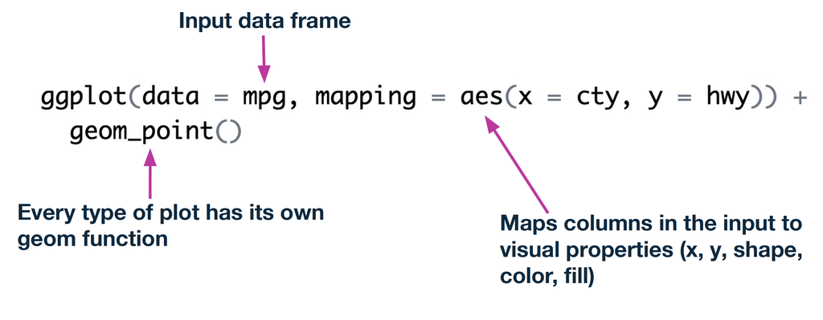

## Plot Example

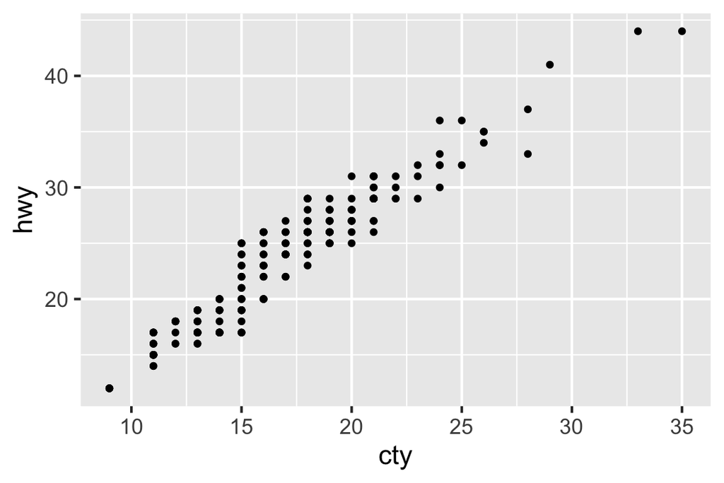

```r
ggplot(data = mpg,                         # Input dataframe
       mapping = aes(x = cty, y = hwy)) +  # Aesthetic mapping
  geom_point()                             # Point graph
```

## Adding and Modifying Layers

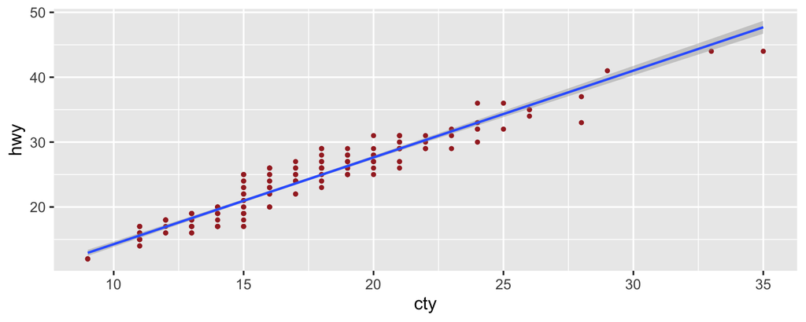

```r
ggplot(data = mpg,
       mapping = aes(x = cty, y = hwy)) +
  geom_point(color = "brown") +
  geom_smooth(formula = y ~ x, method = "lm")
```

# 10 min break

`10:00`

# Hands-on Data Analysis

## Dataset Description

- PanTHERIA
  - A global species-level data set of key traits of all known extant and recently extinct mammals compiled from literature
  - Used in macroecological and macroevolutionary research projects
  - Data is organized by taxonomic rank

## Taxonomic Rank

[figure not shown]

## Data Preview

| Order | Family | Genus | Species | Binomial | ActivityCycle | AdultBodyMass_g | AdultForearmLen_mm | AdultHeadBodyLen_mm | AgeatEyeOpening_d | AgeatFirstBirth_d | BasalMetRate_mLO2hr | BasalMetRateMass_g | DietBreadth | DispersalAge_d | GestationLen_d | HabitatBreadth | HomeRange_km2 | HomeRange_Indiv_km2 | InterbirthInterval_d | LitterSize | LittersPerYear | MaxLongevity_m | NeonateBodyMass_g | NeonateHeadBodyLen_mm | PopulationDensity_n/km2 | PopulationGrpSize | SexualMaturityAge_d | SocialGrpSize | Terrestriality | … |
| --- | --- | --- | --- | --- | --- | --- | --- | --- | --- | --- | --- | --- | --- | --- | --- | --- | --- | --- | --- | --- | --- | --- | --- | --- | --- | --- | --- | --- | --- | --- |
| Carnivora | Canidae | Canis | latrans | Canis latrans | crepuscular | 11989.1 | NA | 872.39 | 11.94 | 365 | 3699 | 10450 | 1 | 255 | 61.74 | 1 | 18.88 | 19.91 | 365 | 5.72 | NA | 262 | 200.01 | NA | 0.25 | NA | 372.9 | NA | fossorial | … |
| Carnivora | Canidae | Canis | lupus | Canis lupus | crepuscular | 31756.51 | NA | 1055 | 14.01 | 547.5 | 11254.2 | 33100 | 1 | 180 | 63.5 | 1 | 159.86000000000001 | 43.13 | 365 | 4.9800000000000004 | 2 | 354 | 412.31 | NA | 0.01 | NA | 679.37 | NA | fossorial | … |
| Carnivora | Canidae | Canis | simensis | Canis simensis | diurnal | 14361.86 | NA | 938.19 | NA | NA | NA | NA | 1 | 180 | 63.61 | 1 | 4.2 | 5.0199999999999996 | 365 | NA | NA | NA | NA | NA | 1.2 | NA | 754.74 | NA | fossorial | … |
| Carnivora | Canidae | Atelocynus | microtis | Atelocynus microtis | NA | 8363.2199999999993 | NA | 831.01 | NA | NA | NA | NA | 1 | NA | NA | 1 | NA | NA | NA | NA | NA | 132 | NA | NA | NA | NA | NA | 1 | fossorial | … |
| Cetacea | Balaenopteridae | Balaenoptera | musculus | Balaenoptera musculus | NA | 154321304.5 | NA | 30480 | NA | NA | NA | NA | 1 | NA | 326.97000000000003 | 1 | NA | NA | 821.25 | 1 | 0.45 | 1320 | 2738612.79 | 7236.55 | NA | 1 | 1959.8 | 1.25 | NA | … |
| Cetacea | Balaenopteridae | Balaenoptera | physalus | Balaenoptera physalus | NA | 47506008.229999997 | NA | 20641.060000000001 | NA | NA | NA | NA | 2 | NA | 338.36 | 1 | NA | NA | 730 | 1.01 | 0.37 | 1392 | 1899999.99 | 6273.75 | NA | 1.5 | 2666.41 | NA | NA | … |

## Hands-on Analysis

- We will read in the data and explore if the trophic level has a significant impact on the adult body mass of mammals

Steps:  
1. Combine and clean the data  
2. Visualize adult body mass by trophic level  
3. Check for overrepresented groups  
4. Fit a simple linear model

## Hands-on Analysis

- Open part_2.Rmd
- If you just want to follow along and not run code, open part2_filled_out.html

# AI Tips for R

## General Tips

- Follow any relevant institutional guidelines on using LLMs
- Always confirm the outputs are correct
- Provide as much detail as possible about the problem in the 1st prompt
- Use separate chats for separate tasks/projects
- Try the ‘Custom Instructions’ function

## Code Tips

- Commented R code yields better responses
- Provide the code and error message in the same prompt
- LLMs can work well to convert syntax and improve your code:
  - “Turn this loop into a function : [your code]”
  - “Is there a better way to do this : [your code]”
- Check out the file: `example_code/1_convert_syntax_example.R` for an example use case

# Where to Get Help

## Bioinformatics Questions

For any bioinformatics specific questions feel free to reach out to the Gladstone Bioinformatics Core.

- Email
  - bioinformatics@gladstone.ucsf.edu
- Slack channel #questions-about-bioinformatics
  - Contact us at the email above to be added to the channel

## Debugging Errors

- Try searching the web by pasting the error message and any relevant keywords (package or function name)
- Websites like [Stack Overflow](https://stackoverflow.com/) and [Posit Community Forum](https://forum.posit.co/) should have the most relevant answers
- If the problem is package specific, check the documentation and reach out to the authors using their preferred method

# Additional Resources

## Coding Templates

Code templates can be used to avoid typing the same code over and over again.

- These are templates can be used to automate things like plot appearance and documentation:
  - [.Rmd Template](https://www.dropbox.com/scl/fi/a9cnyqdajgabbfcxbmm6y/RMD_template.Rmd?rlkey=yntfpo6aptw9b4pgjyzpe5ubi&dl=1)
  - [.R Script Template](https://www.dropbox.com/scl/fi/cy43b8b1x3nzn17esnmmt/Rscript_template.R?rlkey=zn7b0g8nn0s9213blh70fjjsx&dl=1)
- Customize these for your use case to save time

## R Resources

- [R for Data Science](https://r4ds.hadley.nz/)
- [Top 10 R Errors and How to Fix them](https://statsandr.com/blog/top-10-errors-in-r/)
- [R Markdown: The Definitive Guide](https://bookdown.org/yihui/rmarkdown/how-to-read-this-book.html)
- [ggplot2: elegant graphics for data analysis](https://ggplot2-book.org/)
- [Advanced R](https://adv-r.hadley.nz/)

# End of Part 2

## Workshop survey

- Please fill out our [workshop survey](https://www.surveymonkey.com/r/bioinfo-training) so we can continue to improve these workshops

## Upcoming Workshops

**Introduction to Statistics, Experimental Design, and Hypothesis Testing**  
August 25 - August 26, 2025 1:00-3:00pm PDT

**Introduction to RNA-Seq Analysis**  
September 22-September 23, 2025 1:00-3:00pm PDT

**Introduction to Linear Mixed Effects Models**  
September 29-September 30, 2025 1:00-3:00pm PDT

**Working on Wynton**  
October 2-October 3, 2025 9:00am-12:00pm PDT